# Week 2 - Homework

STAT 420, Summer 2023, D. Unger

# Directions

Students are encouraged to work together on homework. However, sharing, copying or providing any part of a homework solution or code is an infraction of the University’s rules on Academic Integrity. Any violation will be punished as severely as possible.

- Be sure to remove this section if you use this `.Rmd` file as a template.
- You may leave the questions in your final document.

## Exercise 1 (Using `lm`)

For this exercise we will use the `cats` dataset from the `MASS` package. You should use `?cats` to learn about the background of this dataset.

**(a)** Suppose we would like to understand the size of a cat’s heart based on the body weight of a cat. Fit a simple linear model in `R` that accomplishes this task. Store the results in a variable called `cat_model`. Output the result of calling `summary()` on `cat_model`.

**Solution:**

```r
df = MASS::cats

cat_model = lm(Hwt ~ Bwt, data = df)
summary(cat_model)
```

```
##
## Call:
## lm(formula = Hwt ~ Bwt, data = df)
##
## Residuals:
##     Min      1Q  Median      3Q     Max
## -3.5694 -0.9634 -0.0921  1.0426  5.1238
##
## Coefficients:
##             Estimate Std. Error t value Pr(>|t|)
## (Intercept)  -0.3567     0.6923  -0.515    0.607
## Bwt           4.0341     0.2503  16.119   <2e-16 ***
## ---
## Signif. codes:  0 '***' 0.001 '**' 0.01 '*' 0.05 '.' 0.1 ' ' 1
##
## Residual standard error: 1.452 on 142 degrees of freedom
## Multiple R-squared:  0.6466, Adjusted R-squared:  0.6441
## F-statistic: 259.8 on 1 and 142 DF,  p-value: < 2.2e-16
```

**(b)** Output only the estimated regression coefficients. Interpret $\hat{\beta_0}$ and $\beta_1$ in the *context of the problem*. Be aware that only one of those is an estimate.

**Solution:**

```r
cat_model$coefficients
```

```
## (Intercept)         Bwt
##  -0.3566624   4.0340627
```

$\hat{\beta_0}$ is an estimate of the true intercept for the linear model explaining the relationship between a cat’s body weight and heart weight. $\beta_1$ is the true coefficient for the linear model between a cat’s heart weight and a cat’s body weight.

**(c)** Use your model to predict the heart weight of a cat that weights **3.1** kg. Do you feel confident in this prediction? Briefly explain.

**Solution:**

```r
pred_hwt = predict(cat_model, newdata = data.frame(Bwt = 3.1))
```

**Predicted Heart Weight:** 12.1489319

Yes, I feel confident in this prediction since the body weight used for the prediction falls inside the range of the observations for body weight.

**(d)** Use your model to predict the heart weight of a cat that weights **1.5** kg. Do you feel confident in this prediction? Briefly explain.

**Solution:**

```r
pred_hwt2 = predict(cat_model, newdata = data.frame(Bwt = 1.5))
```

**Predicted Heart Weight:** 5.6944316

I feel less confident in this prediction since the body weight falls outside the range of the observed body weights for this set of observations.

**(e)** Create a scatterplot of the data and add the fitted regression line. Make sure your plot is well labeled and is somewhat visually appealing.

**Solution:**

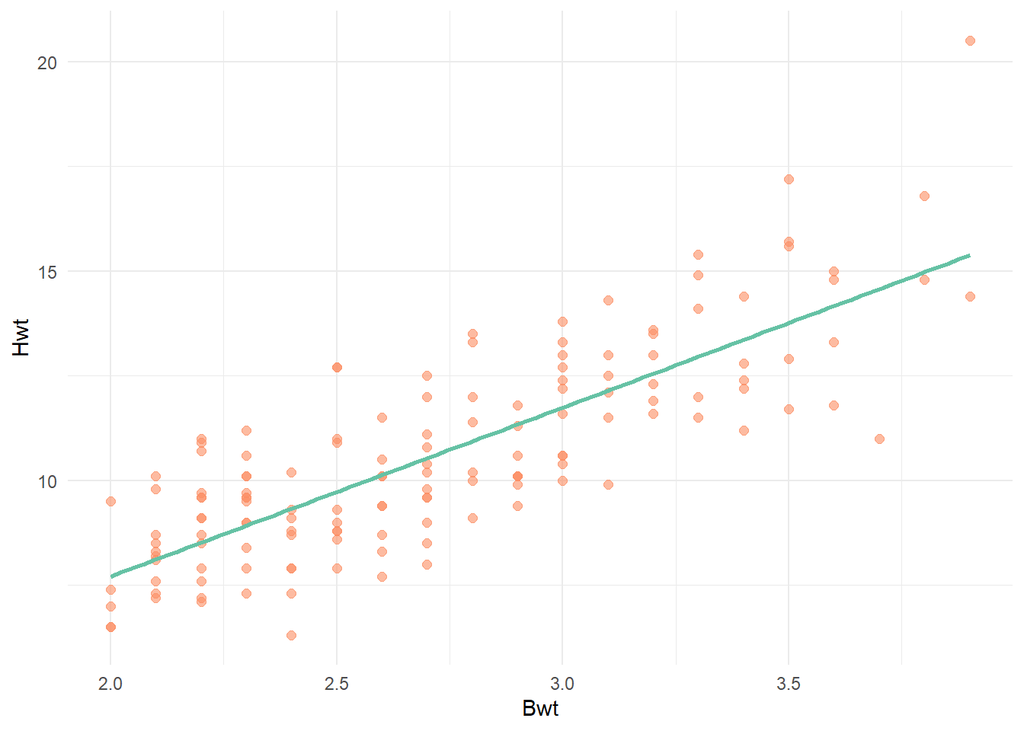

```r
library(ggplot2)

p = ggplot(df, aes(x = Bwt, y = Hwt)) +
  geom_point(color = '#fc8d62', size = 2, alpha = 0.6) +
  geom_smooth(method = 'lm',se = FALSE , color = '#66c2a5') + #formula = 'Hwt ~ Bwt'
  theme_minimal()

p
```

**(f)** Report the value of $R^2$ for the model. Do so directly. Do not simply copy and paste the value from the full output in the console after running `summary()` in part **(a)**.

**Solution:**

```r
#summary(cat_model)
r2 = summary(cat_model)$r.squared
```

The $R^2$ for the model is 0.6466209.

## Exercise 2 (Writing Functions)

This exercise is a continuation of Exercise 1.

**(a)** Write a function called `get_sd_est` that calculates an estimate of $\sigma$ in one of two ways depending on input to the function. The function should take three arguments as input:

- `fitted_vals` - A vector of fitted values from a model
- `actual_vals` - A vector of the true values of the response
- `mle` - A logical (`TRUE` / `FALSE`) variable which defaults to `FALSE`

The function should return a single value:

- $s_e$ if `mle` is set to `FALSE`.
- $\hat{\sigma}$ if `mle` is set to `TRUE`.

**Solution:**

```r
get_sd_est = function(fitted_vals, actual_vals, mle = FALSE){
  # Sum of squares
  squares = (actual_vals - fitted_vals)**2
  ss = sum(squares)

  if(mle == FALSE){
    sd_est = sqrt(ss / (length(fitted_vals) - 2))
  }

  else{
    sd_est = sqrt(ss / (length(fitted_vals)))
  }

  return(sd_est)
}
```

**(b)** Run the function `get_sd_est` on the residuals from the model in Exercise 1, with `mle` set to `FALSE`. Explain the resulting estimate in the context of the model.

**Solution:**

```r
#names(cat_model)
fitted = cat_model$fitted.values
actual = df$Hwt

s_e = get_sd_est(fitted_vals = fitted, actual_vals = actual)
```

$s_e:$ 1.4523733

This estimate is an unbiased estimate for the standard deviation of the model’s fitted values from the observed values.

**(c)** Run the function `get_sd_est` on the residuals from the model in Exercise 1, with `mle` set to `TRUE`. Explain the resulting estimate in the context of the model. Note that we are trying to estimate the same parameter as in part **(b)**.

**Solution:**

```r
sigma_hat_mle = get_sd_est(fitted_vals = fitted, actual_vals = actual, mle = TRUE)
```

$\hat{\sigma}:$ 1.4422522

This estimate is a biased estimate for the standard deviation of the model’s fitted values from the observed values.

**(d)** To check your work, output `summary(cat_model)$sigma`. It should match at least one of **(b)** or **(c)**.

**Solution:**

```r
summary(cat_model)$sigma
```

```
## [1] 1.452373
```

## Exercise 3 (Simulating SLR)

Consider the model

$$Y_i = 5 + -3 x_i + \epsilon_i$$

with

$$\epsilon_i \sim N(\mu = 0, \sigma^2 = 10.24)$$

where $\beta_0 = 5$ and $\beta_1 = -3$.

This exercise relies heavily on generating random observations. To make this reproducible we will set a seed for the randomization. Alter the following code to make `birthday` store your birthday in the format: `yyyymmdd`. For example, [William Gosset](https://en.wikipedia.org/wiki/William_Sealy_Gosset), better known as *Student*, was born on June 13, 1876, so he would use:

```r
birthday = 19790221
set.seed(birthday)
```

**(a)** Use `R` to simulate `n = 25` observations from the above model. For the remainder of this exercise, use the following “known” values of $x$.

**Solution:**

```r
# Model
x = runif(n = 25, 0, 10)
beta_0 = 5
beta_1 = -3
sig = sqrt(10.24)


#Example function from text book
sim_slr = function(x, beta_0 = 5, beta_1 = -3, sigma = sig) {
  n = length(x)
  epsilon = rnorm(n, mean = 0, sd = sigma)
  y = beta_0 + beta_1 * x + epsilon
  data.frame(predictor = x, response = y)
}

# Simulated data
my_sim = sim_slr(x)
```

You may use [the `sim_slr` function provided in the text](http://daviddalpiaz.github.io/appliedstats/simple-linear-regression.html#simulating-slr). Store the data frame this function returns in a variable of your choice. Note that this function calls $y$ `response` and $x$ `predictor`.

**(b)** Fit a model to your simulated data. Report the estimated coefficients. Are they close to what you would expect? Briefly explain.

**Solution:**

```r
# Model fit
my_sim_fit = lm(response ~ predictor, data = my_sim)

# Model coefficients, intercept and slope
cf = coef(my_sim_fit)
intercept = summary(my_sim_fit)$coefficients[1, 1]
slope = summary(my_sim_fit)$coefficients[2, 1]
```

The estimate for $\hat{\beta_1}$ of -3.0503 is fairly close to the actual value of -3 while the estimate for $\hat{\beta_0}$ of 6.0933 does seem to be not as accurate of an estimate of the true $\beta_0$ for this model.

**(c)** Plot the data you simulated in part **(a)**. Add the regression line from part **(b)** as well as the line for the true model. Hint: Keep all plotting commands in the same chunk.

**Solution:**

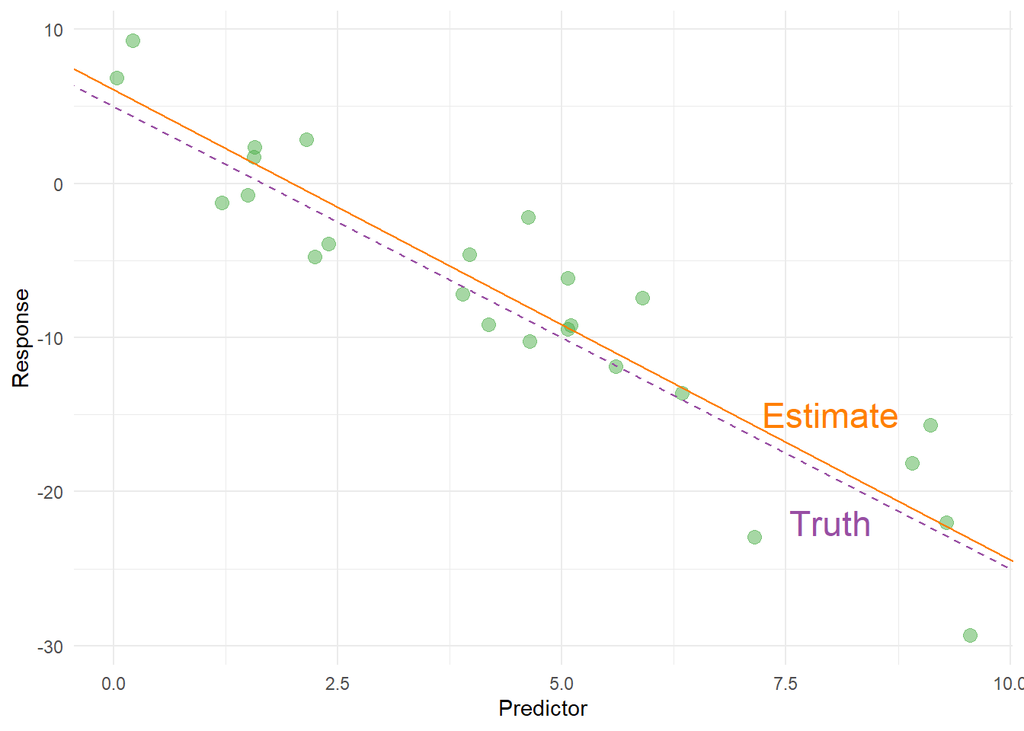

```r
p = ggplot(my_sim, aes(x = predictor, y = response)) +
  geom_point(color = "#4daf4a", size = 3, alpha = .50) +
  # Estimated regression line from model
  geom_abline(slope = slope, intercept = intercept, color = "#ff7f00") +
  annotate('text', x = 8.0, y = -15, label = 'Estimate', color = "#ff7f00", size = 6) +
  # True regression line
  geom_abline(slope = -3, intercept = 5, linetype = 2, color = "#984ea3") +
  annotate('text', x = 8.0, y = -22, label = 'Truth', color = "#984ea3", size = 6) +

  theme_minimal() +
  labs(x = 'Predictor',
       y = 'Response')

p
```

**(d)** Use `R` to repeat the process of simulating `n = 25` observations from the above model $1500$ times. Each time fit a SLR model to the data and store the value of $\hat{\beta_1}$ in a variable called `beta_hat_1`. Some hints:

- Consider a `for` loop.
- Create `beta_hat_1` before writing the `for` loop. Make it a vector of length $1500$ where each element is `0`.
- Inside the body of the `for` loop, simulate new $y$ data each time. Use a variable to temporarily store this data together with the known $x$ data as a data frame.
- After simulating the data, use `lm()` to fit a regression. Use a variable to temporarily store this output.
- Use the `coef()` function and `[]` to extract the correct estimated coefficient.
- Use `beta_hat_1[i]` to store in elements of `beta_hat_1`.
- See the notes on [Distribution of a Sample Mean](http://daviddalpiaz.github.io/appliedstats/introduction-to-r.html#distribution-of-a-sample-mean) for some inspiration.

You can do this differently if you like. Use of these hints is not required.

**Solution:**

```r
# Instantiate vector to hold slope
beta_hat_1 = rep(0, 1500)

# Simulation
for(i in 1:1500){
  # Generate data
  my_sim = sim_slr(x)
  # Fit model with generated data
  my_sim_fit = lm(response ~ predictor, data = my_sim)
  # Get beta_hat
  slope = summary(my_sim_fit)$coefficients[2, 1]

  beta_hat_1[i] = slope
}
```

**(e)** Report the mean and standard deviation of `beta_hat_1`. Do either of these look familiar?

**Solution:**

```r
beta_hat_1_mean = mean(beta_hat_1)
beta_hat_1_sd = sd(beta_hat_1)
```

`beta_hat_1` mean: -2.9992726

`beta_hat_1` standard deviation: 0.2278782

The mean of `beta_hat_1` (-2.9992726) is very close to $\beta_1$ of -3 for the original model.

**(f)** Plot a histogram of `beta_hat_1`. Comment on the shape of this histogram.

**Solution:**

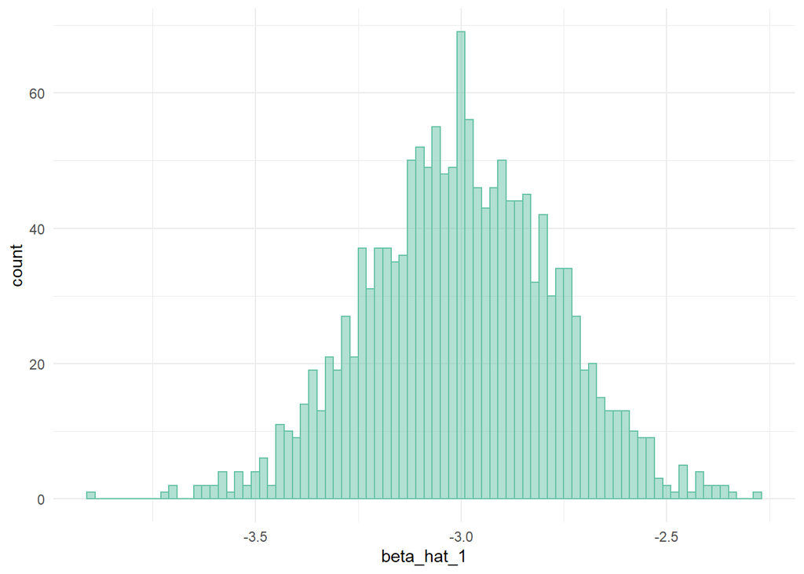

```r
# Convert beta_hat to a dataframe
beta_h = as.data.frame(beta_hat_1)

# Histogram
p_hist = ggplot(beta_h, aes(x = beta_hat_1)) +
  geom_histogram(binwidth = 0.02, fill = '#66c2a5', color = '#66c2a5', alpha = 0.5) +
  theme_minimal()

p_hist
```

The shape of the histogram of `beta_hat_1` is symmetric and centered around -3.0.

## Exercise 4 (Be a Skeptic)

Consider the model

$$Y_i = 3 + 0 \cdot x_i + \epsilon_i$$

with

$$\epsilon_i \sim N(\mu = 0, \sigma^2 = 4)$$

where $\beta_0 = 3$ and $\beta_1 = 0$.

Before answering the following parts, set a seed value equal to **your** birthday, as was done in the previous exercise.

```r
birthday = 19790221
set.seed(birthday)
```

**(a)** Use `R` to repeat the process of simulating `n = 75` observations from the above model $2500$ times. For the remainder of this exercise, use the following “known” values of $x$.

Each time fit a SLR model to the data and store the value of $\hat{\beta_1}$ in a variable called `beta_hat_1`. You may use [the `sim_slr` function provided in the text](http://daviddalpiaz.github.io/appliedstats/simple-linear-regression.html#simulating-slr). Hint: Yes $\beta_1 = 0$.

**Solution:**

```r
x = runif(n = 75, 0, 10)

# Vector to hold results
beta_hat_1 = rep(0, 2500)

# Simulation
for(i in 1:2500){
  # Generate data
  my_sim = sim_slr(x, beta_0 = 3, beta_1 = 0, sigma = 2)
  # Fit model with generated data
  my_sim_fit = lm(response ~ predictor, data = my_sim)
  # Get beta_hat
  slope = summary(my_sim_fit)$coefficients[2, 1]

  beta_hat_1[i] = slope
}
```

**(b)** Plot a histogram of `beta_hat_1`. Comment on the shape of this histogram.

**Solution:**

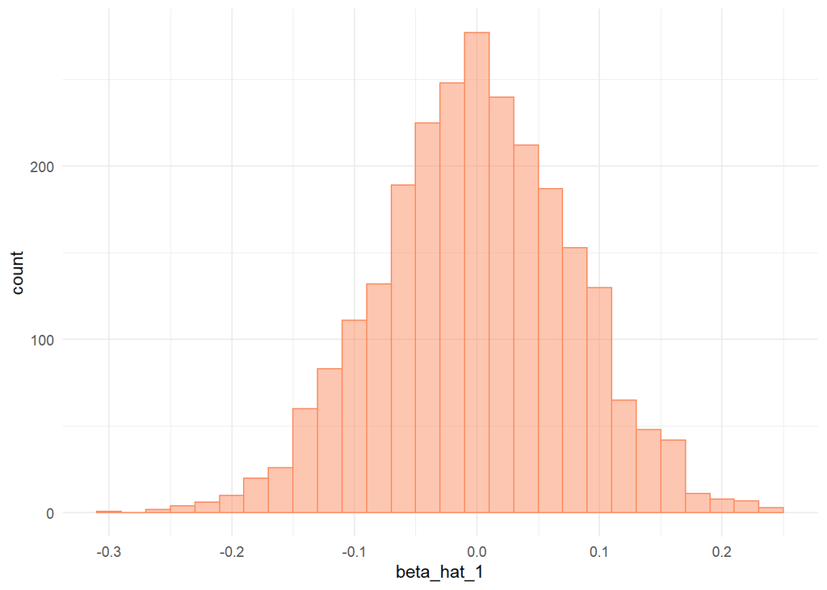

```r
# Convert to dataframe
beta_h = as.data.frame(beta_hat_1)

# Histogram
p_hist = ggplot(beta_h, aes(x = beta_hat_1)) +
  geom_histogram(binwidth = 0.02, fill = '#fc8d62', color = '#fc8d62', alpha = 0.5) +
  theme_minimal()

p_hist
```

The histogram of `beta_hat_1` is centered around 0 with a slight negative skewness.

**(c)** Import the data in `skeptic.csv` and fit a SLR model. The variable names in `skeptic.csv` follow the same convention as those returned by `sim_slr()`. Extract the fitted coefficient for $\beta_1$.

**solution:**

```r
library(tidyverse)
data_skeptic = read_csv('skeptic.csv')

# Model fit
model_skeptic = lm(response ~ predictor, data = data_skeptic)
# Coefficient
beta_1 = summary(model_skeptic)$coefficients[2,1]
beta_1
```

```
## [1] -0.2221927
```

The fitted coefficient for $\beta_1$ is -0.2221927.

**(d)** Re-plot the histogram from **(b)**. Now add a vertical red line at the value of $\hat{\beta_1}$ in part **(c)**. To do so, you’ll need to use `abline(v = c, col = "red")` where `c` is your value.

**Solution:**

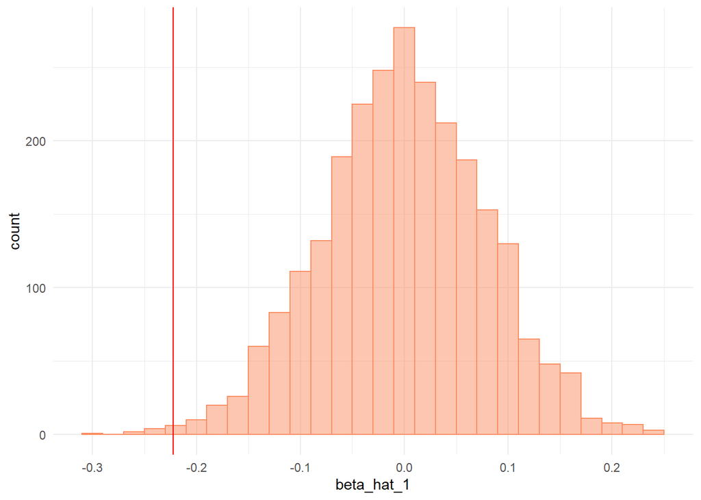

```r
# Add line for beta_hat_1 to previous histogram
p_hist2 = p_hist +
  geom_vline(xintercept = beta_1, color = 'red')

p_hist2
```

**(e)** Your value of $\hat{\beta_1}$ in **(c)** should be negative. What proportion of the `beta_hat_1` values is smaller than your $\hat{\beta_1}$? Return this proportion, as well as this proportion multiplied by `2`.

**Solution:**

```r
# Filter for beta_hat_1 which are less than beta_1
beta_less = beta_hat_1[beta_hat_1 < beta_1]

# Calculate proportion
beta_prop = length(beta_less) / length(beta_hat_1)
beta_prop
```

```
## [1] 0.004
```

The proportion of observations that are smaller than $\hat{\beta_1}$ is 0.004 and the proportion is 0.008 when multiplied by 2.

**(f)** Based on your histogram and part **(e)**, do you think the `skeptic.csv` data could have been generated by the model given above? Briefly explain.

**Solution:**

I do not think that the data from skeptic.csv could have been generated by the model given above since the expected value of $\hat\beta_1$ for skeptic.csv is in tail of the distribution of $\beta_1$ and only 0.4% of simulated observations from the given model are more extreme than the expected value of $\beta_1$ coefficient for the skeptic.csv data.

## Exercise 5 (Comparing Models)

For this exercise we will use the `Ozone` dataset from the `mlbench` package. You should use `?Ozone` to learn about the background of this dataset. You may need to install the `mlbench` package. If you do so, do not include code to install the package in your `R` Markdown document.

For simplicity, we will perform some data cleaning before proceeding.

```r
data(Ozone, package = "mlbench")
Ozone = Ozone[, c(4, 6, 7, 8)]
colnames(Ozone) = c("ozone", "wind", "humidity", "temp")
Ozone = Ozone[complete.cases(Ozone), ]
```

We have:

- Loaded the data from the package
- Subset the data to relevant variables
  - This is not really necessary (or perhaps a good idea) but it makes the next step easier
- Given variables useful names
- Removed any observation with missing values
  - This should be given much more thought in practice

For this exercise we will define the “Root Mean Square Error” of a model as

$$\text{RMSE} = \sqrt{\frac{1}{n} \sum_{i = 1}^{n}(y_i - \hat{y}_i)^2}.$$

**(a)** Fit three SLR models, each with “ozone” as the response. For the predictor, use “wind speed,” “humidity percentage,” and “temperature” respectively. For each, calculate $\text{RMSE}$ and $R^2$. Arrange the results in a markdown table, with a row for each model. Suggestion: Create a data frame that stores the results, then investigate the `kable()` function from the `knitr` package.

**Solution:**

```r
library(kableExtra)

# function for calculating RMSE
get_rmse = function(fitted_vals, actual_vals){
  # Sum of squares
  squares = (actual_vals - fitted_vals)**2
  ss = sum(squares)
  return(sqrt(ss / length(fitted_vals)))

}
# Models
wind = lm(ozone ~ wind, data = Ozone)
humidity = lm(ozone ~ humidity, data = Ozone)
temp = lm(ozone ~ temp, data = Ozone)

# RMSE
wind_rmse = get_rmse(wind$fitted.values, Ozone$ozone)
humidity_rmse = get_rmse(humidity$fitted.values, Ozone$ozone)
temp_rmse = get_rmse(temp$fitted.values, Ozone$ozone)

# R-squared
wind_r2 = summary(wind)$r.squared
humidity_r2 = summary(humidity)$r.squared
temp_r2 = summary(temp)$r.squared

# Create dataframe for output
df = tibble(Predictor = c('Wind', 'Humidity', 'Temperature'),
            RMSE = c(wind_rmse, humidity_rmse, temp_rmse),
            R_squared = c(wind_r2, humidity_r2, temp_r2))

# Table for displaying results
tbl = df %>%
  kbl() %>%
  kable_styling()

tbl
```

| Predictor | RMSE | R_squared |
| --- | --- | --- |
| Wind | 7.961695 | 0.0001402 |
| Humidity | 7.147822 | 0.1941105 |
| Temperature | 5.009257 | 0.6042011 |

**(b)** Based on the results, which of the three predictors used is most helpful for predicting ozone readings? Briefly explain.

**Solution:**

Temperature is the most helpful of the 3 predictors because that model had the lowest RMSE and the highest $R^2$ of the 3 predictors.

## Exercise 00 (SLR without Intercept)

**This exercise will *not* be graded and is simply provided for your information. No credit will be given for the completion of this exercise. Give it a try now, and be sure to read the solutions later.**

Sometimes it can be reasonable to assume that $\beta_0$ should be 0. That is, the line should pass through the point $(0, 0)$. For example, if a car is traveling 0 miles per hour, its stopping distance should be 0! (Unlike what we saw in the book.)

We can simply define a model without an intercept,

$$Y_i = \beta x_i + \epsilon_i.$$

**(a)** [In the **Least Squares Approach** section of the text](http://daviddalpiaz.github.io/appliedstats/simple-linear-regression.html#least-squares-approach) you saw the calculus behind the derivation of the regression estimates, and then we performed the calculation for the `cars` dataset using `R`. Here you need to do, but not show, the derivation for the slope only model. You should then use that derivation of $\hat{\beta}$ to write a function that performs the calculation for the estimate you derived.

In summary, use the method of least squares to derive an estimate for $\beta$ using data points $(x_i, y_i)$ for $i = 1, 2, \ldots n$. Simply put, find the value of $\beta$ to minimize the function

$$f(\beta)=\sum_{i=1}^{n}(y_{i}-\beta x_{i})^{2}.$$

Then, write a function `get_beta_no_int` that takes input:

- `x` - A predictor variable
- `y` - A response variable

The function should then output the $\hat{\beta}$ you derived for a given set of data.

**(b)** Write your derivation in your `.Rmd` file using TeX. Or write your derivation by hand, scan or photograph your work, and insert it into the `.Rmd` as an image. See the [RMarkdown documentation](http://rmarkdown.rstudio.com/) for working with images.

**(c)** Test your function on the `cats` data using body weight as `x` and heart weight as `y`. What is the estimate for $\beta$ for this data?

**(d)** Check your work in `R`. The following syntax can be used to fit a model without an intercept:

```r
lm(response ~ 0 + predictor, data = dataset)
```

Use this to fit a model to the `cat` data without an intercept. Output the coefficient of the fitted model. It should match your answer to **(c)**.